# Nouragues H-D — Tropical Tree Height-Diameter Data, French Guiana

plant_scaling_data project

2026-05-02

# 1 Overview

**NouraguesHD** is a paired height-diameter dataset for tropical trees in the Nouragues Natural Reserve, French Guiana. It is distributed as part of the **BIOMASS** R package (Réjou-Méchain et al. 2017) and is used as a reference dataset for fitting local height-diameter models in tropical forest AGB estimation workflows.

The Nouragues Reserve is a pristine, undisturbed lowland tropical moist forest in central French Guiana (~4°N, 52–53°W), with no recent logging or major anthropogenic disturbance.

> **BIOMASS R package (data source):** Réjou-Méchain M, Tanguy A, Piponiot C, Chave J, Hérault B (2017). BIOMASS: an R Package for estimating aboveground biomass and its uncertainty in tropical forests. *Methods in Ecology and Evolution* 8:1163–1167. doi: 10.1111/2041-210X.12753

> **⚠ Citation note:** The primary literature citation for the NouraguesHD dataset within the BIOMASS package should be verified — the package documentation credits Réjou-Méchain et al. (2017) as the package reference but does not provide a separate DOI for the dataset itself. The field measurements originate from the Nouragues long-term research station.

# 2 Top-level summary

```r
n_sp <- length(unique(paste(dat$genus, dat$species)[
  dat$genus != "indet" & dat$species != "indet"]))

kable(data.frame(
  Metric = c(
    "Total trees",
    "Trees with height (H)",
    "Unique plots",
    "Unique genera",
    "Unique identified species (excl. indet)",
    "DBH range (cm)",
    "Height range (m)",
    "Latitude range (\u00b0N)",
    "Longitude range (\u00b0E)",
    "Forest type",
    "Country",
    "Source in R",
    "License / access"
  ),
  Value = c(
    format(nrow(dat), big.mark = ","),
    format(sum(!is.na(dat$H)), big.mark = ","),
    length(unique(dat$plotId)),
    length(unique(dat$genus)),
    n_sp,
    paste0(min(dat$D, na.rm=TRUE), "\u2013",
           round(max(dat$D, na.rm=TRUE), 1)),
    paste0(min(dat$H, na.rm=TRUE), "\u2013",
           max(dat$H, na.rm=TRUE)),
    paste0(round(min(dat$lat),3), "\u2013", round(max(dat$lat),3)),
    paste0(round(min(dat$long),3), "\u2013", round(max(dat$long),3)),
    "Tropical moist forest (undisturbed, lowland)",
    "France (French Guiana, ~4\u00b0N 52\u201353\u00b0W)",
    "BIOMASS::NouraguesHD",
    "Available via BIOMASS package (CRAN) — no separate download required"
  ),
  stringsAsFactors = FALSE
), caption = "Nouragues H-D top-level summary")
```

Nouragues H-D top-level summary

| Metric | Value |
| --- | --- |
| Total trees | 1,051 |
| Trees with height (H) | 888 |
| Unique plots | 2 |
| Unique genera | 113 |
| Unique identified species (excl. indet) | 133 |
| DBH range (cm) | 10–159.2 |
| Height range (m) | 5–54 |
| Latitude range (°N) | 4.037–4.068 |
| Longitude range (°E) | -52.688–-52.674 |
| Forest type | Tropical moist forest (undisturbed, lowland) |
| Country | France (French Guiana, ~4°N 52–53°W) |
| Source in R | BIOMASS::NouraguesHD |
| License / access | Available via BIOMASS package (CRAN) — no separate download required |

# 3 Geographic context

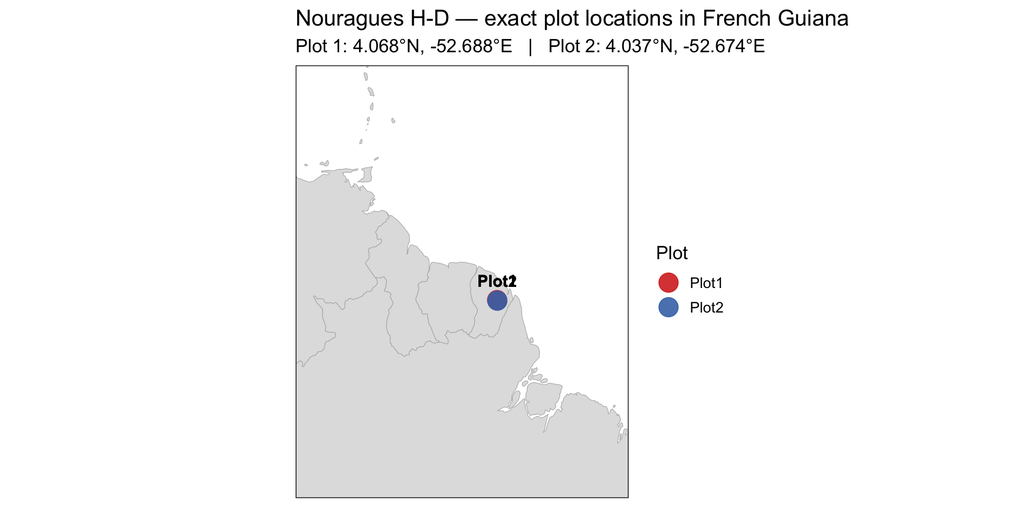

```r
world <- map_data("world")

# Exact plot coordinates from data
plot_coords <- dat |>
  distinct(plotId, lat, long)

ggplot() +
  geom_polygon(data = world,
               aes(x = long, y = lat, group = group),
               fill = "grey88", color = "grey70", linewidth = 0.2) +
  geom_point(data = plot_coords,
             aes(x = long, y = lat, color = plotId),
             size = 6, alpha = 0.9) +
  geom_text(data = plot_coords,
            aes(x = long, y = lat, label = plotId),
            vjust = -1.2, size = 4, fontface = "bold") +
  coord_fixed(1.3, xlim = c(-65, -45), ylim = c(-5, 15)) +
  scale_color_manual(values = c(Plot1 = "#d73027", Plot2 = "#4575b4")) +
  labs(
    title = "Nouragues H-D \u2014 exact plot locations in French Guiana",
    subtitle = paste0("Plot 1: ", round(plot_coords$lat[1],3), "\u00b0N, ",
                      round(plot_coords$long[1],3), "\u00b0E   |   ",
                      "Plot 2: ", round(plot_coords$lat[2],3), "\u00b0N, ",
                      round(plot_coords$long[2],3), "\u00b0E"),
    x = NULL, y = NULL, color = "Plot"
  ) +
  theme(axis.text = element_blank(), axis.ticks = element_blank(),
        panel.grid = element_blank())
```

# 4 Data structure

```r
kable(data.frame(
  Column      = names(dat),
  Type        = sapply(dat, class),
  N_nonNA     = sapply(dat, function(x) sum(!is.na(x))),
  Pct_complete= paste0(sapply(dat, function(x)
    round(100*mean(!is.na(x)), 1)), "%"),
  Description = c(
    "Plot identifier (Plot1 or Plot2)",
    "Genus name (indet if undetermined)",
    "Species epithet (indet if undetermined)",
    "Diameter at breast height (cm); all >= 10 cm",
    "Total tree height (m); 163 NAs (height not measured for all trees)",
    "Plot centroid latitude (\u00b0N, WGS84)",
    "Plot centroid longitude (\u00b0E, WGS84)"
  ),
  stringsAsFactors = FALSE
), caption = "NouraguesHD column descriptions")
```

NouraguesHD column descriptions

|  | Column | Type | N_nonNA | Pct_complete | Description |
| --- | --- | --- | --- | --- | --- |
| plotId | plotId | character | 1051 | 100% | Plot identifier (Plot1 or Plot2) |
| genus | genus | character | 1051 | 100% | Genus name (indet if undetermined) |
| species | species | character | 1051 | 100% | Species epithet (indet if undetermined) |
| D | D | numeric | 1051 | 100% | Diameter at breast height (cm); all >= 10 cm |
| H | H | numeric | 888 | 84.5% | Total tree height (m); 163 NAs (height not measured for all trees) |
| lat | lat | numeric | 1051 | 100% | Plot centroid latitude (°N, WGS84) |
| long | long | numeric | 1051 | 100% | Plot centroid longitude (°E, WGS84) |

# 5 Diameter distribution

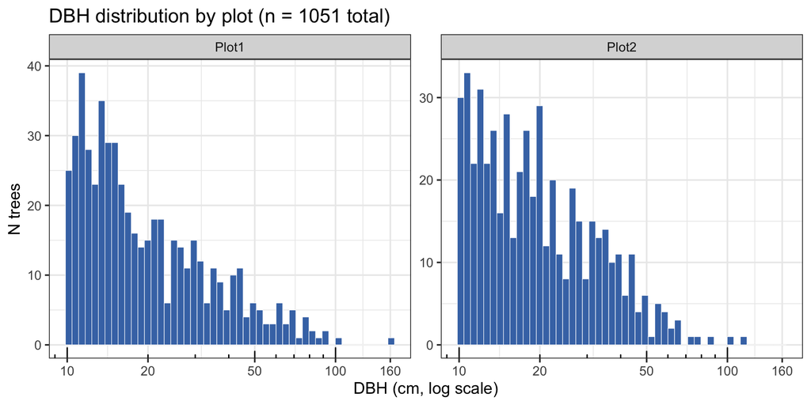

```r
dat |>
  ggplot(aes(x = D)) +
  geom_histogram(bins = 50, fill = "#4575b4", color = "white", linewidth = 0.2) +
  scale_x_log10(labels = comma, breaks = c(10, 20, 50, 100, 160)) +
  annotation_logticks(sides = "b") +
  scale_y_continuous(labels = comma) +
  facet_wrap(~ plotId, scales = "free_y") +
  labs(
    x = "DBH (cm, log scale)", y = "N trees",
    title = paste0("DBH distribution by plot (n = ", nrow(dat), " total)")
  )
```

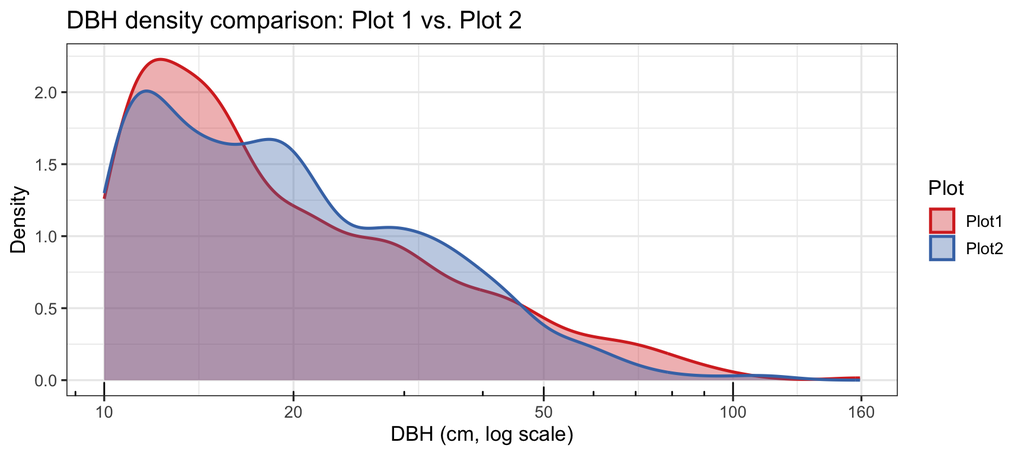

```r
dat |>
  ggplot(aes(x = D, fill = plotId, color = plotId)) +
  geom_density(alpha = 0.35, linewidth = 0.9, adjust = 0.8) +
  scale_x_log10(labels = comma, breaks = c(10, 20, 50, 100, 160)) +
  annotation_logticks(sides = "b") +
  scale_fill_manual(values  = c(Plot1 = "#d73027", Plot2 = "#4575b4")) +
  scale_color_manual(values = c(Plot1 = "#d73027", Plot2 = "#4575b4")) +
  labs(
    x = "DBH (cm, log scale)", y = "Density",
    title = "DBH density comparison: Plot 1 vs. Plot 2",
    fill = "Plot", color = "Plot"
  )
```

```r
dbh_stats <- dat |>
  group_by(plotId) |>
  summarise(
    N        = n(),
    Min_cm   = round(min(D, na.rm=TRUE), 1),
    P25_cm   = round(quantile(D, 0.25, na.rm=TRUE), 1),
    Median_cm= round(median(D, na.rm=TRUE), 1),
    Mean_cm  = round(mean(D, na.rm=TRUE), 1),
    P75_cm   = round(quantile(D, 0.75, na.rm=TRUE), 1),
    Max_cm   = round(max(D, na.rm=TRUE), 1),
    .groups  = "drop"
  )
kable(dbh_stats, caption = "DBH summary statistics by plot")
```

DBH summary statistics by plot

| plotId | N | Min_cm | P25_cm | Median_cm | Mean_cm | P75_cm | Max_cm |
| --- | --- | --- | --- | --- | --- | --- | --- |
| Plot1 | 533 | 10 | 12.6 | 16.6 | 23.2 | 27.7 | 159.2 |
| Plot2 | 518 | 10 | 12.6 | 18.0 | 22.4 | 28.1 | 116.2 |

# 6 Height distribution

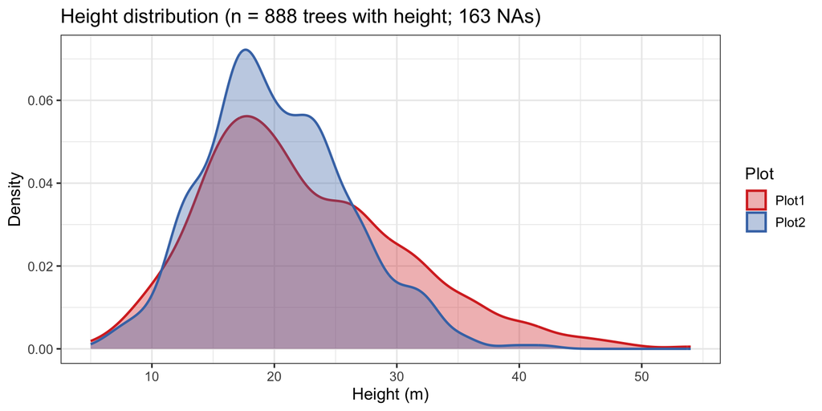

```r
dat |>
  filter(!is.na(H)) |>
  ggplot(aes(x = H, fill = plotId, color = plotId)) +
  geom_density(alpha = 0.35, linewidth = 0.9, adjust = 0.8) +
  scale_fill_manual(values  = c(Plot1 = "#d73027", Plot2 = "#4575b4")) +
  scale_color_manual(values = c(Plot1 = "#d73027", Plot2 = "#4575b4")) +
  labs(
    x = "Height (m)", y = "Density",
    title = paste0("Height distribution (n = ", sum(!is.na(dat$H)),
                   " trees with height; ", sum(is.na(dat$H)), " NAs)"),
    fill = "Plot", color = "Plot"
  )
```

```r
ht_stats <- dat |>
  filter(!is.na(H)) |>
  group_by(plotId) |>
  summarise(
    N_with_H = n(),
    Min_m    = round(min(H), 1),
    P25_m    = round(quantile(H, 0.25), 1),
    Median_m = round(median(H), 1),
    Mean_m   = round(mean(H), 1),
    P75_m    = round(quantile(H, 0.75), 1),
    Max_m    = round(max(H), 1),
    .groups  = "drop"
  )
kable(ht_stats, caption = "Height summary statistics by plot (excl. NAs)")
```

Height summary statistics by plot (excl. NAs)

| plotId | N_with_H | Min_m | P25_m | Median_m | Mean_m | P75_m | Max_m |
| --- | --- | --- | --- | --- | --- | --- | --- |
| Plot1 | 455 | 5 | 16 | 21.0 | 22.3 | 27 | 54 |
| Plot2 | 433 | 6 | 16 | 19.5 | 20.2 | 24 | 42 |

> **163 trees (15.5%) have no height measurement.** Height was not measured for every tree in the field campaign. Missing heights must be imputed using the H~D model when computing AGB via the Chave et al. (2014) pantropical equation.

# 7 Height ~ DBH scaling

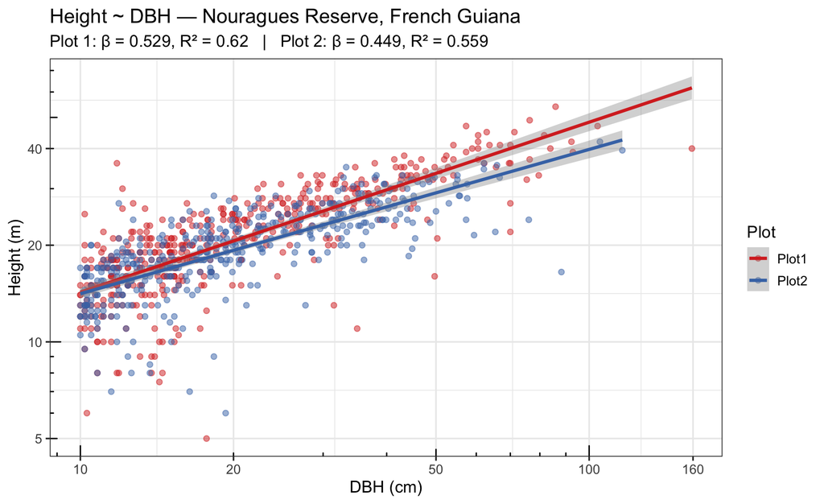

```r
dat_hd <- dat |> filter(!is.na(H), D > 0, H > 0)

# Per-plot OLS log-log
models <- dat_hd |>
  group_by(plotId) |>
  summarise(
    n    = n(),
    beta = round(coef(lm(log(H) ~ log(D)))[2], 3),
    R2   = round(summary(lm(log(H) ~ log(D)))$r.squared, 3),
    .groups = "drop"
  )

ggplot(dat_hd, aes(x = D, y = H, color = plotId)) +
  geom_point(alpha = 0.5, size = 1.8) +
  geom_smooth(method = "lm", formula = y ~ x,
              se = TRUE, linewidth = 1.2) +
  scale_x_log10(labels = comma, breaks = c(10, 20, 50, 100, 160)) +
  scale_y_log10(labels = comma, breaks = c(5, 10, 20, 40)) +
  annotation_logticks() +
  scale_color_manual(values = c(Plot1 = "#d73027", Plot2 = "#4575b4")) +
  labs(
    x = "DBH (cm)", y = "Height (m)",
    title = "Height ~ DBH — Nouragues Reserve, French Guiana",
    subtitle = paste0(
      "Plot 1: \u03b2 = ", models$beta[1], ", R\u00b2 = ", models$R2[1],
      "   |   Plot 2: \u03b2 = ", models$beta[2], ", R\u00b2 = ", models$R2[2]
    ),
    color = "Plot"
  )
```

```r
kable(models,
      col.names = c("Plot", "N (with height)", "\u03b2 (slope)", "R\u00b2"),
      caption   = paste0(
        "OLS log-log Height ~ DBH exponents per plot. ",
        "\u26a0 OLS underestimates the slope when both variables carry error; ",
        "use SMA or the Michaelis-Menten / Weibull model for formal inference ",
        "(as recommended by the BIOMASS package)."))
```

OLS log-log Height ~ DBH exponents per plot. ⚠ OLS underestimates the slope when both variables carry error; use SMA or the Michaelis-Menten / Weibull model for formal inference (as recommended by the BIOMASS package).

| Plot | N (with height) | β (slope) | R² |
| --- | --- | --- | --- |
| Plot1 | 455 | 0.529 | 0.620 |
| Plot2 | 433 | 0.449 | 0.559 |

## 7.1 Weibull and Michaelis-Menten models (as used in BIOMASS)

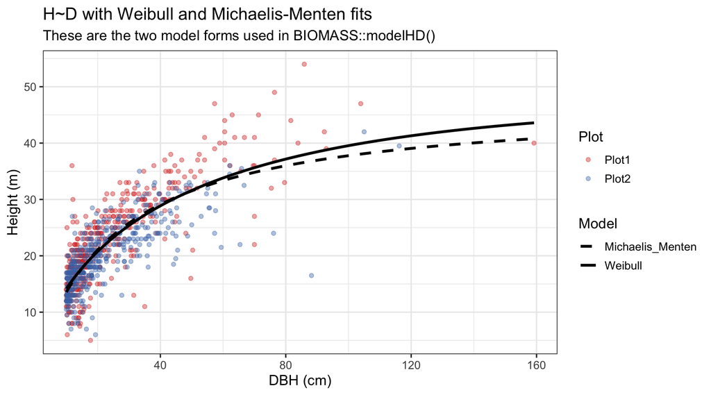

```r
# Fit the models used in BIOMASS::modelHD
dat_fit <- dat |> filter(!is.na(H), D > 0, H > 0)

# Weibull 3-parameter: H = a(1 - exp(-b*D^c))
weib_fit <- nls(H ~ a * (1 - exp(-b * D^c)),
                data = dat_fit,
                start = list(a = 50, b = 0.05, c = 0.7),
                control = nls.control(maxiter = 200))

# Michaelis-Menten: H = (a*D)/(b+D)
mm_fit   <- nls(H ~ (a * D) / (b + D),
                data = dat_fit,
                start = list(a = 60, b = 20),
                control = nls.control(maxiter = 200))

dbh_seq <- seq(min(dat_fit$D), max(dat_fit$D), length.out = 200)

pred_df <- data.frame(
  D     = dbh_seq,
  Weibull        = predict(weib_fit, newdata = data.frame(D = dbh_seq)),
  Michaelis_Menten = predict(mm_fit, newdata = data.frame(D = dbh_seq))
) |>
  pivot_longer(-D, names_to = "Model", values_to = "H_pred")

ggplot(dat_fit, aes(x = D, y = H, color = plotId)) +
  geom_point(alpha = 0.4, size = 1.5) +
  geom_line(data = pred_df,
            aes(x = D, y = H_pred, linetype = Model),
            color = "black", linewidth = 1.2,
            inherit.aes = FALSE) +
  scale_color_manual(values = c(Plot1 = "#d73027", Plot2 = "#4575b4")) +
  scale_linetype_manual(values = c(Weibull = "solid", Michaelis_Menten = "dashed")) +
  labs(
    x = "DBH (cm)", y = "Height (m)",
    title = "H~D with Weibull and Michaelis-Menten fits",
    subtitle = "These are the two model forms used in BIOMASS::modelHD()",
    color = "Plot", linetype = "Model"
  )
```

```r
kable(data.frame(
  Model = c("Weibull 3-parameter", "Michaelis-Menten"),
  Formula = c("H = a(1 \u2212 e^{\u2212b \u00b7 D^c})", "H = (a \u22c5 D) / (b + D)"),
  AIC = c(round(AIC(weib_fit), 1), round(AIC(mm_fit), 1)),
  RSE = c(round(summary(weib_fit)$sigma, 3), round(summary(mm_fit)$sigma, 3)),
  Note = c("Asymptotic with flexible curvature",
           "Asymptotic; simpler parameterisation"),
  stringsAsFactors = FALSE
), caption = "Non-linear H~D model fit statistics (all plots combined)")
```

Non-linear H~D model fit statistics (all plots combined)

| Model | Formula | AIC | RSE | Note |
| --- | --- | --- | --- | --- |
| Weibull 3-parameter | H = a(1 − e^{−b · D^c}) | 5082.4 | 4.221 | Asymptotic with flexible curvature |
| Michaelis-Menten | H = (a ⋅ D) / (b + D) | 5087.9 | 4.236 | Asymptotic; simpler parameterisation |

# 8 Taxonomic composition

## 8.1 Genera breakdown

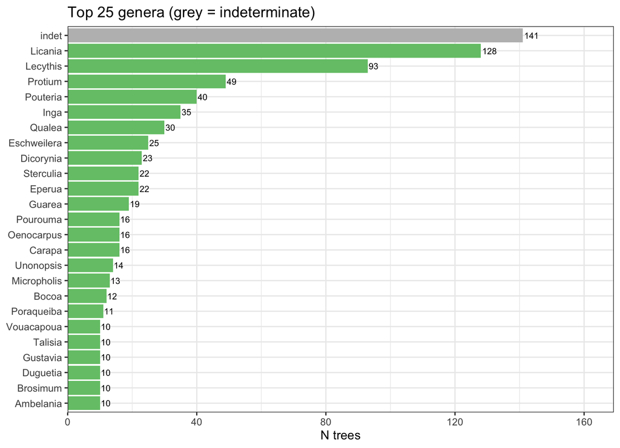

```r
dat |>
  count(genus, sort = TRUE) |>
  head(25) |>
  ggplot(aes(x = reorder(genus, n), y = n, fill = genus == "indet")) +
  geom_col(show.legend = FALSE) +
  geom_text(aes(label = n), hjust = -0.1, size = 3.2) +
  coord_flip() +
  scale_y_continuous(expand = expansion(mult = c(0, 0.2))) +
  scale_fill_manual(values = c("TRUE" = "#bdbdbd", "FALSE" = "#74c476")) +
  labs(
    x = NULL, y = "N trees",
    title = "Top 25 genera (grey = indeterminate)"
  )
```

```r
n_indet <- sum(dat$genus == "indet" | dat$species == "indet")
n_sp_id <- nrow(dat) - n_indet

kable(data.frame(
  Category = c("Fully identified (genus + species)",
               "Indeterminate (indet genus or species)",
               "Identification rate"),
  N = c(format(n_sp_id, big.mark=","),
        format(n_indet, big.mark=","),
        paste0(round(100*n_sp_id/nrow(dat), 1), "%")),
  stringsAsFactors = FALSE
), caption = "Taxonomic identification completeness")
```

Taxonomic identification completeness

| Category | N |
| --- | --- |
| Fully identified (genus + species) | 526 |
| Indeterminate (indet genus or species) | 525 |
| Identification rate | 50% |

## 8.2 Top 20 identified species

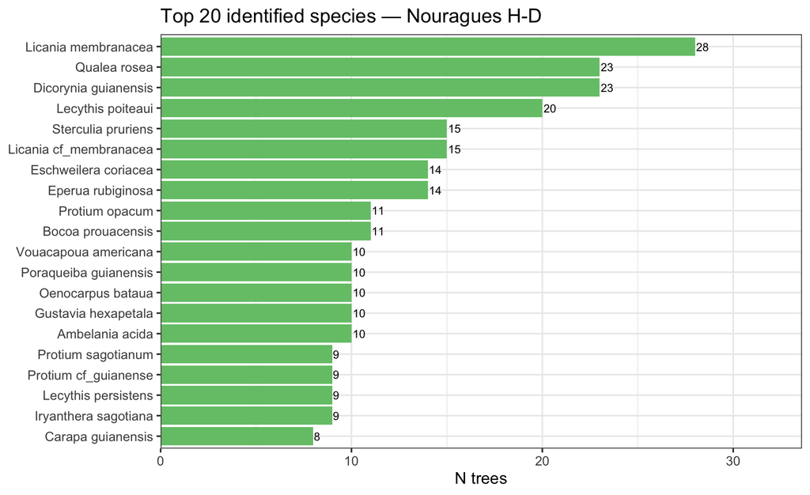

```r
dat |>
  filter(genus != "indet", species != "indet") |>
  mutate(species_name = paste(genus, species)) |>
  count(species_name, sort = TRUE) |>
  head(20) |>
  ggplot(aes(x = reorder(species_name, n), y = n)) +
  geom_col(fill = "#74c476") +
  geom_text(aes(label = n), hjust = -0.1, size = 3.2) +
  coord_flip() +
  scale_y_continuous(expand = expansion(mult = c(0, 0.2))) +
  labs(
    x = NULL, y = "N trees",
    title = "Top 20 identified species \u2014 Nouragues H-D"
  )
```

# 9 DBH ~ Height by top genera

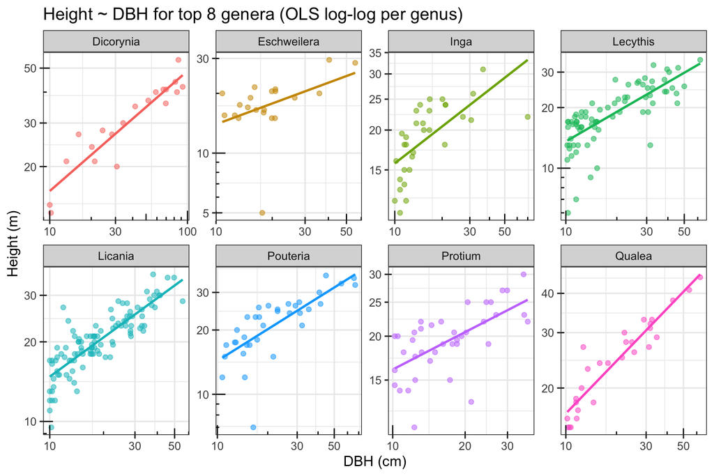

```r
top_genera <- dat |>
  filter(genus != "indet", !is.na(H)) |>
  count(genus, sort = TRUE) |>
  head(8) |>
  pull(genus)

dat |>
  filter(genus %in% top_genera, !is.na(H), D > 0, H > 0) |>
  ggplot(aes(x = D, y = H, color = genus)) +
  geom_point(alpha = 0.55, size = 1.8) +
  geom_smooth(method = "lm", formula = y ~ x,
              se = FALSE, linewidth = 1) +
  scale_x_log10(labels = comma) + scale_y_log10(labels = comma) +
  annotation_logticks() +
  facet_wrap(~ genus, scales = "free", ncol = 4) +
  labs(
    x = "DBH (cm)", y = "Height (m)",
    title = "Height ~ DBH for top 8 genera (OLS log-log per genus)"
  ) +
  theme(legend.position = "none")
```

# 10 Use in BIOMASS AGB estimation

The NouraguesHD dataset is the default training data for `BIOMASS::modelHD()`, which fits local height-diameter models as an intermediate step in Chave et al. (2014) pantropical AGB estimation.

```r
# Example workflow (not run — requires wood density lookup)
library(BIOMASS)

# 1. Fit a local H~D model using Nouragues data
hd_model <- modelHD(
  D      = NouraguesHD$D,
  H      = NouraguesHD$H,
  method = "weibull"   # or "michaelis", "log1", "log2", "log3"
)

# 2. Predict heights for your trees
H_pred <- predictHD(D = my_trees$DBH_cm, model = hd_model, plot = FALSE)

# 3. Get wood densities
wd <- getWoodDensity(genus = my_trees$genus, species = my_trees$species)

# 4. Compute AGB with Chave et al. 2014 eq. 4
AGB <- computeAGB(D = my_trees$DBH_cm, WD = wd$meanWD, H = H_pred$H,
                  coord = cbind(my_trees$long, my_trees$lat))
```

> **Caveat:** Using Nouragues H-D to predict heights for forests *outside* French Guiana introduces systematic bias proportional to the difference in local H-D relationships. Local calibration data are preferred wherever available.

# 11 Data completeness

```r
compl <- data.frame(
  Column = names(dat),
  N_nonNA = sapply(dat, function(x) sum(!is.na(x))),
  Pct = paste0(sapply(dat, function(x) round(100*mean(!is.na(x)),1)), "%"),
  stringsAsFactors = FALSE
)
kable(compl, caption = "Column completeness (n = 1,051 trees)")
```

Column completeness (n = 1,051 trees)

|  | Column | N_nonNA | Pct |
| --- | --- | --- | --- |
| plotId | plotId | 1051 | 100% |
| genus | genus | 1051 | 100% |
| species | species | 1051 | 100% |
| D | D | 1051 | 100% |
| H | H | 888 | 84.5% |
| lat | lat | 1051 | 100% |
| long | long | 1051 | 100% |

# 12 Notes for allometric merging

1. **DBH range is >= 10 cm** — this is a canopy-tree dataset. It lacks saplings and small trees (< 10 cm DBH), which limits its use as a universal H~D calibration dataset.
2. **Only 2 plots, same reserve** — all data come from one site (Nouragues). H-D relationships trained here may not transfer well to other tropical regions.
3. **163 NAs in height** — trees without height measurements must be imputed before using the Chave et al. (2014) AGB equation, which requires height as input.
4. **DBH units are cm** — compatible with BAAD, Tallo, and NEON (no conversion needed).
5. **Taxonomy uses genus + species columns** (not a single `scientificName`); concatenate them before merging with other sources.
6. **Coordinates are plot centroids**, not individual tree positions.